# Practical Machine Learning - Course Project

Joaquin Marques

January 11, 2017

## Introduction

Using devices such as Jawbone Up, Nike FuelBand, and Fitbit it is now possible to collect a large amount of data about personal activity relatively inexpensively. These type of devices are part of the quantified self movement – a group of enthusiasts who take measurements about themselves regularly to improve their health, to find patterns in their behavior, or because they are tech geeks. One thing that people regularly do is quantify how much of a particular activity they do, but they rarely quantify how well they do it. In this project, our goal will be to use data from accelerometers on the belt, forearm, arm, and dumbell of 6 participants. They were asked to perform barbell lifts correctly and incorrectly in 5 different ways. More information is available from the website here: http://groupware.les.inf.puc-rio.br/har (see the section on the Weight Lifting Exercise Dataset).

### Objective

The goal of this project is to predict the manner in which the subjects did the exercise. This is the “classe” variable in the training set. The data used was obtained from the following study:

Velloso, E.; Bulling, A.; Gellersen, H.; Ugulino, W.; Fuks, H. Qualitative Activity Recognition of Weight Lifting Exercises. Proceedings of 4th International Conference in Cooperation with SIGCHI (Augmented Human ’13) . Stuttgart, Germany: ACM SIGCHI, 2013.

### Load training and validation sets

```r
setwd("/Users/jmmg57/Documents/Education/Coursera/Data Science Course - John Hopkins University/Machine Learning")
training <- read.csv(url("http://d396qusza40orc.cloudfront.net/predmachlearn/pml-training.csv"),
                  na.strings=c("NA","#DIV/0!",""))
validation <- read.csv(url("http://d396qusza40orc.cloudfront.net/predmachlearn/pml-testing.csv"),
                 na.strings=c("NA","#DIV/0!",""))
```

### Partition training set into train and test sets

```r
library(caret)
inTrain <- createDataPartition(training$classe, p=0.6, list=FALSE)
train <- training[inTrain, ]
test <- training[-inTrain, ]
dim(train)
```

```
## [1] 11776   160
```

```r
dim(test)
```

```
## [1] 7846  160
```

### Data Cleanup

#### Remove variables with near zero variance, for they contribute very little to result

```r
nzv <- nearZeroVar(train, saveMetrics=TRUE)
train <- train[,nzv$nzv==FALSE]
nzv<- nearZeroVar(test,saveMetrics=TRUE)
test <- test[,nzv$nzv==FALSE]
dim(train)
```

```
## [1] 11776   130
```

```r
dim(test)
```

```
## [1] 7846  132
```

#### Remove first column (“X” or row number) from train dataset

```r
train <- train[c(-1)]
dim(train)
```

```
## [1] 11776   129
```

#### Remove train cols with more than 75% NAs

```r
train <- train[, -which(colMeans(is.na(train)) > 0.75)]
dim(train)
```

```
## [1] 11776    58
```

### Feature Extraction

#### Get test dataset columns in sync with train dataset columns

#### Keep only relevant “acceleration” + classe columns

```r
# Convert set x of column labels (character strings) to set of indices of same columns in dataframe df
getColIndices <- function(x,df) {
    result <- c()
    names <- colnames(df)
    for (i in 1:length(x)) {
        index <- match(x[[i]],names)
        if(!is.na(index)) {
            result <- append(result,index)
        }
    }
    result
}

library(plyr)
library(dplyr)
train <- train[,grep("accel_|classe",colnames(train))]
dim(train)
```

```
## [1] 11776    17
```

```r
nzv <- nearZeroVar(train, saveMetrics=TRUE)
train <- train[,nzv$nzv==FALSE]
cols <- getColIndices(colnames(train),test)
test <- select(test,cols)
cols <- getColIndices(colnames(train),validation)
validation <- select(validation,cols)
dim(train)
```

```
## [1] 11776    17
```

```r
dim(test)
```

```
## [1] 7846   17
```

```r
dim(validation)
```

```
## [1] 20 16
```

```r
colnames(train)
```

```
##  [1] "total_accel_belt"     "accel_belt_x"         "accel_belt_y"
##  [4] "accel_belt_z"         "total_accel_arm"      "accel_arm_x"
##  [7] "accel_arm_y"          "accel_arm_z"          "total_accel_dumbbell"
## [10] "accel_dumbbell_x"     "accel_dumbbell_y"     "accel_dumbbell_z"
## [13] "total_accel_forearm"  "accel_forearm_x"      "accel_forearm_y"
## [16] "accel_forearm_z"      "classe"
```

#### Determine if any of the remaining predictors is not important

```r
library(Boruta)
train1 <- train
train1 <- train1[complete.cases(train1),]
convert <- c(1:ncol(train1))
train1[,convert] <- data.frame(apply(train1[convert], 2, as.factor))
set.seed(123)
boruta.train <- Boruta(classe~., data = train1, doTrace = 0)
print(boruta.train)
```

```
## Boruta performed 11 iterations in 43.26452 secs.
##  16 attributes confirmed important: accel_arm_x, accel_arm_y,
## accel_arm_z, accel_belt_x, accel_belt_y and 11 more.
##  No attributes deemed unimportant.
```

Conclusion: All predictors are important!

#### Let us plot the importance of the predictors:

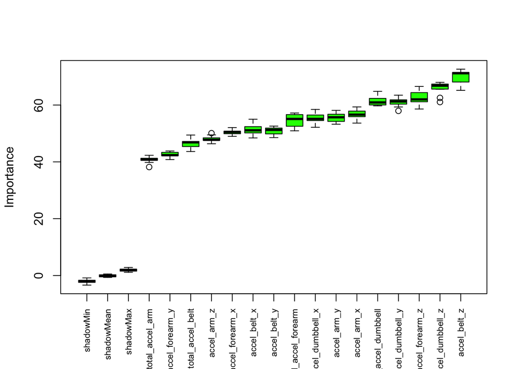

```r
plot(boruta.train, xlab = "", xaxt = "n")
lz<-lapply(1:ncol(boruta.train$ImpHistory),function(i)
    boruta.train$ImpHistory[is.finite(boruta.train$ImpHistory[,i]),i])
names(lz) <- colnames(boruta.train$ImpHistory)
Labels <- sort(sapply(lz,median))
axis(side = 1,las=2,labels = names(Labels),
     at = 1:ncol(boruta.train$ImpHistory), cex.axis = 0.7)
```

### Model Selection & Optimization

I initially tried gbm as a model and got very high Accuracy (84.7%), and hence low expected sample error, so I decided to see how much a gbm model could be optimized using the caret package. I set up a grid with 3 interaction.depths (1, 5, 9), 30 trees of 50 each, and constant shrinkage = 0.1 with at least 20 objects per node. I set up the control for cross validation with number=5 and repeats=3, and trained the model with metric=“ROC”

```r
library(caret)
gbmGrid <-  expand.grid(interaction.depth = c(1, 5, 9),
                        n.trees = (1:30)*50,
                        shrinkage = 0.1,
                        n.minobsinnode = 20)
control <- trainControl(method="repeatedcv", number=5, repeats=3, classProbs = TRUE)

set.seed(1234)
gbm_fit <- train(classe~., data=train, method="gbm",  metric="ROC", tuneGrid = gbmGrid, trControl=control, verbose=FALSE)
```

The gbm model’s training optimization results

```r
print(gbm_fit)
```

```
## Stochastic Gradient Boosting
##
## 11776 samples
##    16 predictor
##     5 classes: 'A', 'B', 'C', 'D', 'E'
##
## No pre-processing
## Resampling: Cross-Validated (5 fold, repeated 3 times)
## Summary of sample sizes: 9420, 9420, 9420, 9422, 9422, 9420, ...
## Resampling results across tuning parameters:
##
##   interaction.depth  n.trees  Accuracy   Kappa
##   1                    50     0.5563015  0.4306923
##   1                   100     0.6079044  0.4990851
##   1                   150     0.6385027  0.5389649
```

[output cut: 94 more lines]

Plot the gbm model’s accuracy vs. # boosting interactions for the 3 interaction.depths (1, 5, 9)

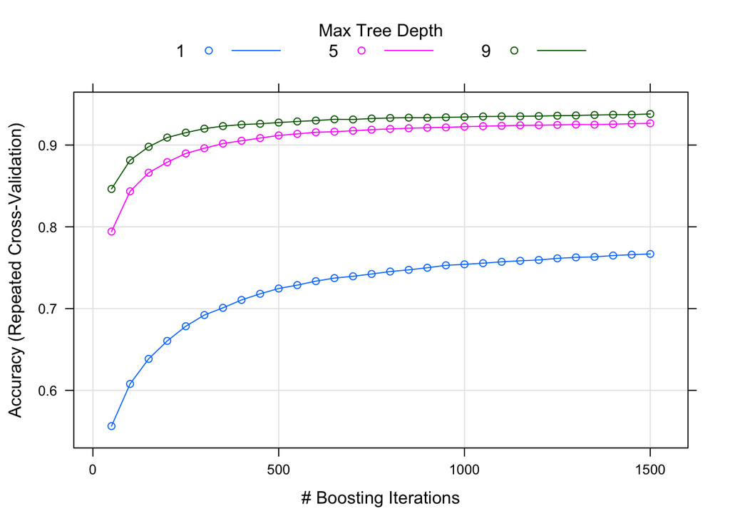

```r
plot(gbm_fit)
```

### Prediction Results

#### Use prediction model to predict test cases.

#### Use confusion matrix to compare predicted with actual results

```r
predictions <- predict(gbm_fit, newdata = test)
cm <- confusionMatrix(predictions, test$classe)
print(cm, digits=4)
```

```
## Confusion Matrix and Statistics
##
##           Reference
## Prediction    A    B    C    D    E
##          A 2129   63   29   42    3
##          B   26 1381   44    3   22
##          C   38   47 1283   62   12
##          D   38   10   10 1167   24
##          E    1   17    2   12 1381
##
## Overall Statistics
##
##                Accuracy : 0.9356
##                  95% CI : (0.93, 0.941)
##     No Information Rate : 0.2845
##     P-Value [Acc > NIR] : < 2.2e-16
##
##                   Kappa : 0.9185
##  Mcnemar's Test P-Value : 2.843e-11
##
## Statistics by Class:
##
##                      Class: A Class: B Class: C Class: D Class: E
## Sensitivity            0.9539   0.9097   0.9379   0.9075   0.9577
## Specificity            0.9756   0.9850   0.9755   0.9875   0.9950
## Pos Pred Value         0.9395   0.9356   0.8897   0.9343   0.9774
## Neg Pred Value         0.9815   0.9785   0.9867   0.9820   0.9905
## Prevalence             0.2845   0.1935   0.1744   0.1639   0.1838
## Detection Rate         0.2713   0.1760   0.1635   0.1487   0.1760
## Detection Prevalence   0.2888   0.1881   0.1838   0.1592   0.1801
## Balanced Accuracy      0.9647   0.9474   0.9567   0.9475   0.9764
```

#### We now use prediction model to predict 20 different validation cases.

#### Because validation set includes no classe column, we cannot use a

#### confusion matrix to compare predicted with actual results.

#### Here is the list of possible results:

#### - Class A: exactly according to the specification

#### - Class B: throwing the elbows to the front

#### - Class C: lifting the dumbbell only halfway

#### - Class D: lowering the dumbbell only half way

#### - Class E: throwing the hips to the front.

#### Only Class A indicates correct execution. The rest indicate common mistakes.

```r
predictions <- predict(gbm_fit, newdata = validation)
predictions
```

```
##  [1] B A B A A E D B A A B C B A E E A B B B
## Levels: A B C D E
```

#### Accuracy and Expected sample error

```r
accuracy <- cm$overall[[1]]
accuracy
```

```
## [1] 0.935636
```

```r
sampleError <- round((1 - accuracy)*100,2)
sampleError
```

```
## [1] 6.44
```

```r
options(warn = oldw)
```